# problem set 2

```r
# assuming all your files are within a directory called 'data/stop-search'
data_dir <- "data/stop-search"

files <- fs::dir_ls(path = data_dir, regexp = "\\.csv$", recurse = TRUE)
#recurse=TRUE will recursively look for files further down into any folders

#read them all in using vroom::vroom()
stop_search_data <- vroom(files, id = "source")

# Use janitor to clean names, and add more variables
stop_search_all <- stop_search_data %>%
  janitor::clean_names() %>%
  mutate(month = month(date),
         month_name = month(date, label=TRUE, abbr = TRUE),
         year= year(date),
         month_year = paste0(year, "-",month_name)
  )

# rename longitude/latitude to lng/lat
names(stop_search_all)[names(stop_search_all) == 'longitude'] <- 'lng'
names(stop_search_all)[names(stop_search_all) == 'latitude'] <- 'lat'
```

## Visualization 1

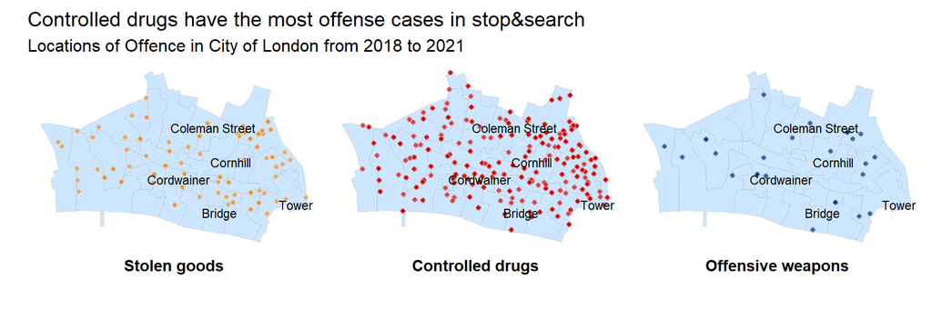

```r
#use sf::read_sf() to read in London Wards shapefile
london_wards_sf <- read_sf(here("data/London-wards-2018_ESRI/London_Ward.shp"))

# transfrom CRS to 4326, or pairs of latitude/longitude numbers
london_wgs84 <-  london_wards_sf %>%
  st_transform(4326) # transfrom CRS to WGS84, latitude/longitude

city_of_london_wgs84 <- london_wards_sf %>%
  filter(DISTRICT == "City and County of the City of London") %>%
  st_transform(4326)

# concentrate in top three searches, age_ranges, and officer defined ethnicities
which_searches <- c("Stolen goods", "Controlled drugs", "Offensive weapons")
which_ages <- c("10-17", "18-24","25-34", "over 34")
which_ethnicity <- c("White", "Black", "Asian")

stop_search_offence <- stop_search_all %>%

  # filter out stop-and-search where no further action was taken
  filter(outcome != "A no further action disposal") %>%

  #filter out  rows with no latitude/longitude
  filter(!is.na(lng)) %>%
  filter(!is.na(lat)) %>%

  # concentrate in top searches, age_ranges, and officer defined ethnicities
  filter(object_of_search %in% which_searches) %>%
  filter(age_range %in% which_ages) %>%
  filter(officer_defined_ethnicity %in% which_ethnicity) %>%

  # only select the area in city of London borrow

  # relevel factors so everything appears in correct order
  mutate(
    object_of_search = fct_relevel(object_of_search,
                                   c("Stolen goods", "Controlled drugs", "Offensive weapons")),
    age_range = fct_relevel(age_range,
                            c( "10-17","18-24", "25-34", "over 34")),
    officer_defined_ethnicity = fct_relevel(officer_defined_ethnicity,
                                            c("White", "Black", "Asian"))
  )

# transform points to sf
stops_sf <- st_as_sf(stop_search_offence%>%select(lng, lat),
                     coords = c('lng',"lat"),
                     crs = st_crs(city_of_london_wgs84))
# intersection of polygons and points
stop_locations <- stops_sf %>%
  mutate(intersection = as.integer(st_intersects(geometry, city_of_london_wgs84$geometry)),
         area = if_else(is.na(intersection), '', city_of_london_wgs84$NAME[intersection]),
         district = if_else(is.na(intersection), '', city_of_london_wgs84$DISTRICT[intersection]))

# split geometry in coordinates
stop_locations <- stop_locations%>%
  mutate(X= st_coordinates(geometry)[,1],
         Y= st_coordinates(geometry)[,2])

# append areas and borough to stop search
stop_search_offence$area <- stop_locations$area
stop_search_offence$district <- stop_locations$district
stop_search_offence$geometry <- stop_locations$geometry

stop_search_offence_centre <- stop_search_offence %>%
  filter(area != "")

# NB: make sure to transform to a  common CRS.
# Here we retrieve and apply the CRS of london_wgs84
city_of_london_stop_search_offence_sf <-  st_as_sf(stop_search_offence_centre,
                              coords=c('lng', 'lat'),
                              crs=st_crs(city_of_london_wgs84))

set.seed(100)
ggplot() +
  # draw polygons from London wards shapefile
  geom_sf(data = city_of_london_wgs84, fill = "#cce6ff", size = 0.125, colour = "#b2b2b277") +

  # add points from stop-and-search shapefile
  geom_sf(
    data = city_of_london_stop_search_offence_sf, aes(fill = object_of_search),
    color = "white", size = 1.5, alpha = 0.7, shape = 21,
    show.legend = FALSE
  ) +
  geom_sf_text(data = city_of_london_wgs84[sample(nrow(city_of_london_wgs84), 5), ],
               aes(label = NAME),
               size = 3,
               color = "black")+
  scale_fill_manual(values=c("#e69138", "#cc0000", "#002776")) +
  theme_minimal()+
  coord_sf(datum = NA) + #remove coordinates
  facet_wrap(~object_of_search,strip.position="bottom") +
  labs(title = "Controlled drugs have the most offense cases in stop&search",
       subtitle = "Locations of Offence in City of London from 2018 to 2021",
       x="",
       y="") +
  theme(axis.text = element_blank()) +
  theme(strip.text = element_text(color = "black", face = "bold", size=11))+
  theme(title = element_text(size=12))+
  NULL
```

## Visualization 2

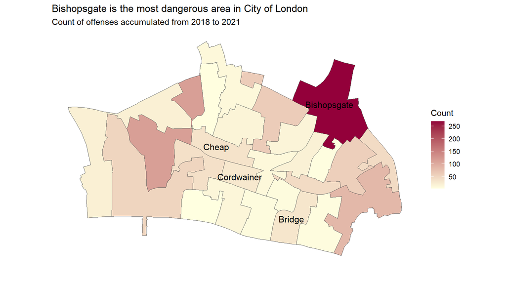

```r
## what if we wanted to calculate number of offenses in each area in City of London
temp <- stop_search_offence_centre %>%
  group_by(area) %>%
  summarise(Count = n())

london_offense_ward <- city_of_london_wgs84 %>%
  left_join(temp, by=c("NAME" = "area"))

my_scale <- c('#ffffe0', '#93003a')

london_offense_ward %>%
  ggplot() +
  geom_sf(mapping = aes(fill = Count),
          color = "grey30", size = 0.25) +
  geom_sf_text(data = city_of_london_wgs84 %>% filter(NAME == "Bishopsgate"|NAME == "Cheap"|NAME == "Bridge"|NAME == "Cordwainer"),
               aes(label = NAME),
               size = 4,
               color = "black")+
  labs(fill = "Count",
       x="",
       y="",
       title = "Bishopsgate is the most dangerous area in City of London",
       subtitle = "Count of offenses accumulated from 2018 to 2021")+
  coord_sf(datum = NA) +
  scale_fill_gradientn(colours = my_scale)+
  theme_classic()+
  theme(
    # Hide panel borders and remove grid lines
    panel.border = element_blank())+
  NULL
```

## Visualization 3

```r
#Compared to Jan-Sept 2020, which areas has seen more offenses in Jan-Sept 2021?
stop_search_offence_2020 <- stop_search_offence_centre %>%
  filter(year == "2020",
         month %in% (1:9)) %>%
  group_by(area) %>%
  summarise(count_2020=n()) %>%
  rename(a = area)

stop_search_offence_2021 <- stop_search_offence_centre %>%
  filter(year == "2021",
         month %in% (1:9)) %>%
  group_by(area) %>%
  summarise(count_2021=n())

stop_search_offence_change <- stop_search_offence_2020 %>%
  left_join(stop_search_offence_2021, by = c("a" = "area")) %>%
  mutate(delta = 100*(count_2021-count_2020)/count_2020)

change <- city_of_london_wgs84 %>%
  left_join(stop_search_offence_change, by=c("NAME" = "a"))

tmap::tmap_mode("view")
tmap::tm_shape(change) +
  tm_polygons("delta",
              palette = "Reds",
              title='% change in offenses yearly',
              title.position = c('right', 'bottom')) +
  tm_layout(title= 'Billingsgate has the 300% increase in offense from 2020 to 2021',
            title.position = c('right', 'top'),
            legend.position = c("left","bottom"))
```

[interactive chart not shown]

memo:

- What story are you telling with your visualizations?

I tried to deliver to the audience what are the most condensed offense boroughs in central london, and the main types of offense (controlled drugs, offensive weapons, stolen goods). The first graph will provide the audience a clue of where are the spots they should beware of. The second visualization is trying to tell the audience that over the years, which borough has the most cases of offense. It shows that one area (Bishopsgate) is the most dangerous one. However, since number of offense cases keep changing over the years, it’s necessary to see which areas has increased crime than others. And with visualization 3 we found that Bishopsgate has decreased crime, but high number of crimes. In comparison, though billingsgate has low number of crimes, it has risen 300% over the past year. Therefore, the audience need to beware of billingsgate on top of bishopsgate.

- How do you apply the principles of C.R.A.P?

The color contrast of map background, the dots and text labels are high enough for audience to visualize. There are repeated plots for each category of offense in the first visualization. Alignment is in place since the titles and subtitles are aligned to the far left. Proximity is in place since the plots grouped by categories of offense.

- How did you apply Alberto Cairo’s five qualities of great visualizations?